# Did people in the past only live to 30–35?

Bulletproof board · HMD public summary + HLD mid-adult ladder · cluster-bootstrapped · de-duplicated · gates PASS

**Scope:** High-quality vital-registration populations (HMD public summary), not all premodern humans. Period life expectancy ≠ lived cohort lifespan. Conditional ages require surviving to that age.

### Claim A — not “died at 30”

75.4

Median expected age if alive at 65 when e0<40  
(cluster 95% CI 75.1–75.7)  
Share ≥70: **100%** · n=211  
Median S(0→65)=0.27 · IMR=196/1000  
Gate A: PASS

### Claim A2 — mid-adult (age 15)

55.9

### Claim B — adults improved

+8.5y

Mean rise in e65 pre-1900 → post-2000  
Cluster 95% CI 7.7–9.1  
n countries=12  
Gate B: PASS

### Claim C — infant mechanism

-0.94

Median within-country corr(e0, IMR)  
First-diff β(ΔIMR)=-0.113  
Associational only — not causal  
Gate C: PASS

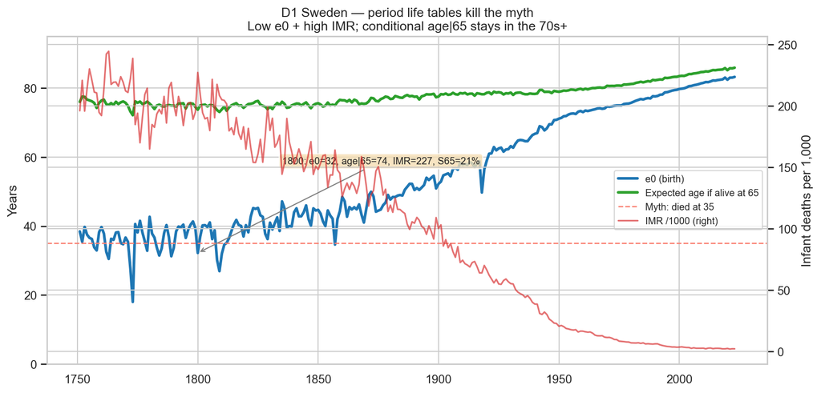

Sweden long run: e0, age|65, IMR

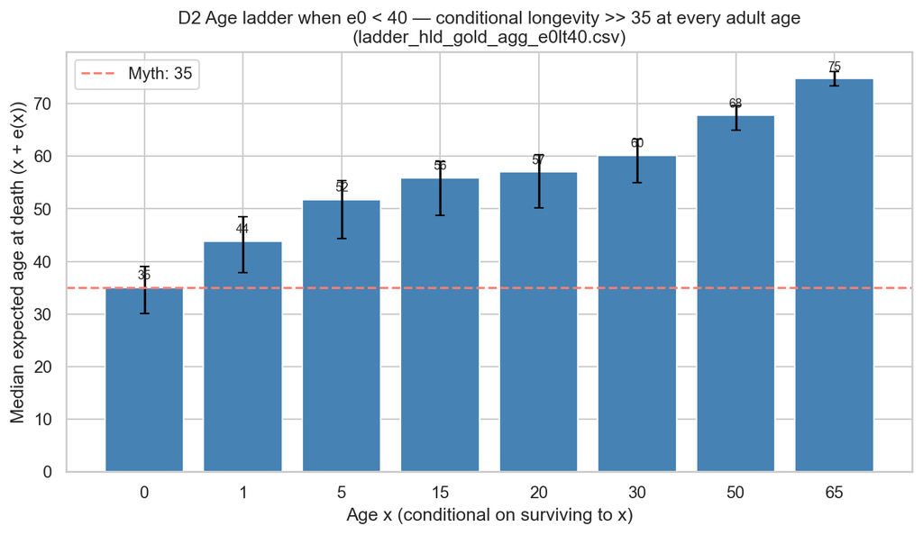

Age ladder when e0<40 — hole-free multi-age

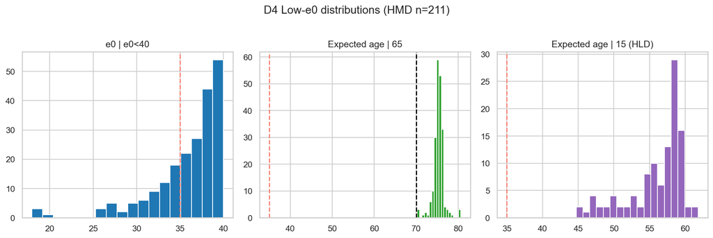

Distributions under the myth threshold

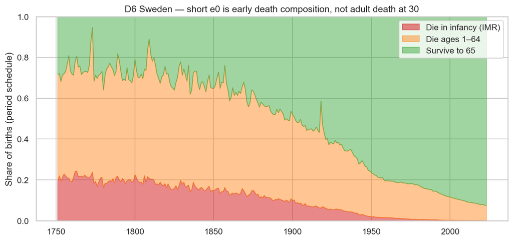

Early death composition

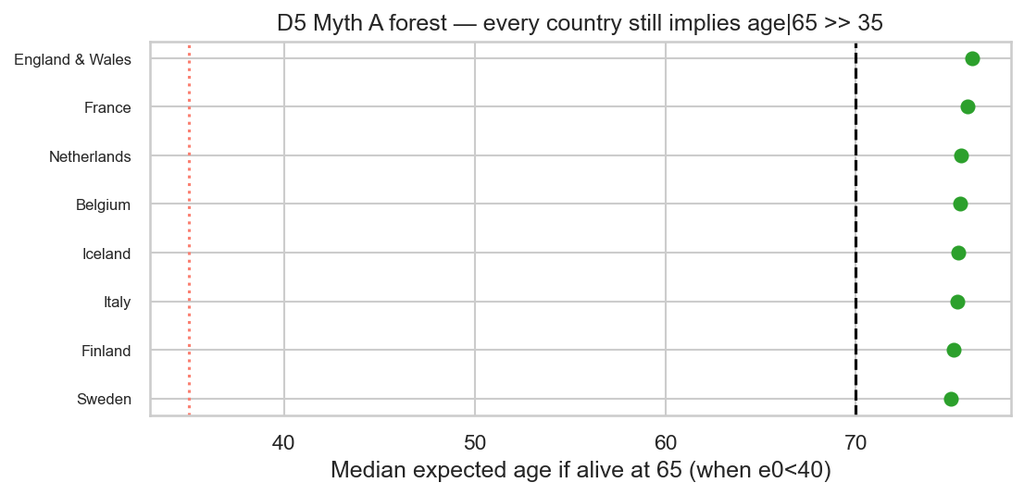

Every country: age|65 still high when e0 low

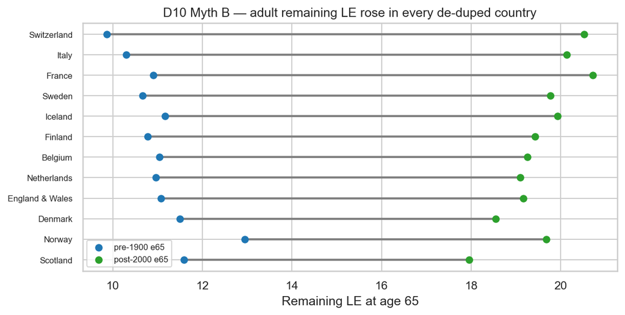

Adult remaining LE rose

## What we are not claiming

- That everyone reached 65 (or 15) historically — survival shares are low.
- That this describes all global premodern populations outside VR data.
- That regressions identify causal effects of infant mortality.
- That period e0 equals the lifespan of a real birth cohort.

Regenerate: `python -m src.analysis.run_next_level` · Full writeup: MYTH_BUST_BULLETPROOF.md